# L03 — Markers & Manual Cell-Type Annotation

## Where this lecture fits

- Previous: Lec 02 — Dim Reduction & Clustering
- **You are here:** Lec 03 — *finding markers and turning clusters into named cell types by hand*
- Next: Lec 04 — Reference-based Annotation
- Multi-sample integration follows in Lec 05 — Multi-Sample Integration
- **Companion tutorial:** Tutorial 03 — Markers & Manual Annotation
- **Companion book chapter:** Chapter 3 — Markers & Manual Cell-Type Annotation

## Goals of this lecture

- Distinguish **clusters** (a graph property) from **cell types** (a biological label)
- Find robust cluster markers with `FindAllMarkers` / `FindConservedMarkers`
- Read DotPlots / FeaturePlots like a clinician
- Assign labels you can defend with literature

**Note**

**Why this matters.** A cluster is a partition of a graph. A *cell type* is a biological claim. Going from one to the other is the most subjective step in the entire workflow — and the one reviewers will scrutinize most.

# Clusters are not cell types

## The annotation workflow

[figure not shown]

## The annotation workflow

- **Manual** (this lecture) — interpretable but biased by the annotator
- **Automatic / reference-based** (Lec 04) — fast and reproducible but biased by the reference
- Best practice: run both, reconcile disagreements, document choices

**Note**

**Which do you reach for first?**

- For **well-referenced model organisms (human, mouse)**, reference-based annotation (Lec 04 — Azimuth; other tools include SingleR and CellTypist) is increasingly the practical *starting* point, with manual markers used to confirm and to catch novel states.
- For **non-model systems** — where no curated reference exists — manual, marker-driven annotation remains essential and is often the *only* option. This workshop teaches both so you can choose based on your system; the two lectures are a connected pair, not alternatives.

# Finding markers

## `FindAllMarkers` — every cluster vs. all others

This step allows you to identify markers that differentiate a cluster against all other clusters:

```r
markers <- FindAllMarkers(seu,
                          only.pos        = TRUE,
                          min.pct         = 0.25,
                          logfc.threshold = 0.25)

markers |>
  group_by(cluster) |>
  slice_max(avg_log2FC, n = 10)
```

- `only.pos = TRUE` keeps just the up-regulated markers (what you’d actually use to *name* a cluster)
- `min.pct = 0.25` requires the gene be detected in at least 25% of cells in either group
- Default test is the Wilcoxon rank-sum

**Tip**

**Defaults that work for most 10x datasets.** `min.pct = 0.25`, `logfc.threshold = 0.25`. Loosen them for very small clusters, tighten them only if results are overwhelming.

## `FindConservedMarkers` — markers that hold across conditions

When your dataset has multiple conditions (e.g. stimulated vs. control PBMCs in the `ifnb` example), you usually want markers that define a cluster **regardless of condition**:

```r
DefaultAssay(seu) <- "RNA"
cluster3_markers <- FindConservedMarkers(seu,
                                         ident.1       = 3,
                                         grouping.var  = "stim")
head(cluster3_markers)
```

This runs the marker test **inside each condition** and reports genes that come up in both — protecting you from labelling a cluster by a treatment-induced gene rather than its lineage marker.

**Warning**

**Don’t skip this step in case-control designs.**

- Naïve `FindAllMarkers` on a stim-vs-ctrl dataset will surface treatment-response genes as “cluster markers”, and you’ll mis-label populations.

## `FindAllMarkers` & `FindConservedMarkers` — what’s shared

Both answer the same underlying question — **“which genes mark this cluster?”** — with the **same machinery**:

- Compare **one cluster vs. all other cells** (a one-vs-rest contrast)
- Run the **same per-gene DE test** under the hood — default **Wilcoxon rank-sum** (`test.use` applies to both)
- Honor the **same filters**: `min.pct`, `logfc.threshold`, `only.pos`
- Return the **same per-gene statistics**: `avg_log2FC`, `p_val`, `p_val_adj`, and the detection rates `pct.1` / `pct.2`

**Note**

So the *building block* is identical — `FindConservedMarkers` is essentially `FindMarkers` run repeatedly. What changes is **how condition is handled** (next slide).

## `FindAllMarkers` vs. `FindConservedMarkers` — what differs

|  | `FindAllMarkers` | `FindConservedMarkers` |
| --- | --- | --- |
| **Question** | What distinguishes a cluster? | What marks a cluster *in every condition*? |
| **Condition** | Pools all cells, **ignores** it | Splits by `grouping.var`, tests **within each** |
| **Clusters** | **Loops over all** automatically | **One** per call (`ident.1`) |
| **Significance** | Single test per gene | Per-condition tests **combined** (meta-analysis) |
| **Output** | One frame, has a `cluster` column | Per-condition columns (`CTRL_…`, `STIM_…`) + combined p-values |
| **Needs** | — | `metap`; enough cluster cells **in each** group |
| **Use when** | Single condition, or just want identity | Case–control / multi-condition designs |

**Tip**

**The trap it avoids.** Pooling stim-vs-ctrl, `FindAllMarkers` can surface a **treatment-response** gene as a “cluster marker.” `FindConservedMarkers` keeps only genes that mark the cluster **within both** CTRL and STIM — so you label by **lineage**, not treatment.

# Reading marker plots well

## What a “good” marker looks like

- **Specific** — high in the cluster, low elsewhere (DotPlot’s dot *intensity*)
- **Pervasive** — expressed in most cells of the cluster (DotPlot’s dot *size*)
- **Backed by literature** — appears in canonical lineage panels for the tissue

## The five marker visualizations

Tutorial 03 walks through five canonical plots that are each best for a different question:

| Plot | What it shows | When to use it |
| --- | --- | --- |
| `VlnPlot` | distribution per cluster, one gene at a time | Bimodality, outliers, comparing 4–8 candidate markers |
| `FeaturePlot` | one gene, every cell, on the UMAP | Spatial structure on the embedding |
| `DoHeatmap` | top-N markers across clusters, cell-by-cell | Eyeballing the global cluster ↔︎ marker structure |
| `RidgePlot` | density per cluster | Gradient / continuum genes |
| `DotPlot` | mean expr × % positive, per (cluster × gene) | Compact panel display — best for the publication figure |

## VlnPlot — one gene per cluster, distribution-aware

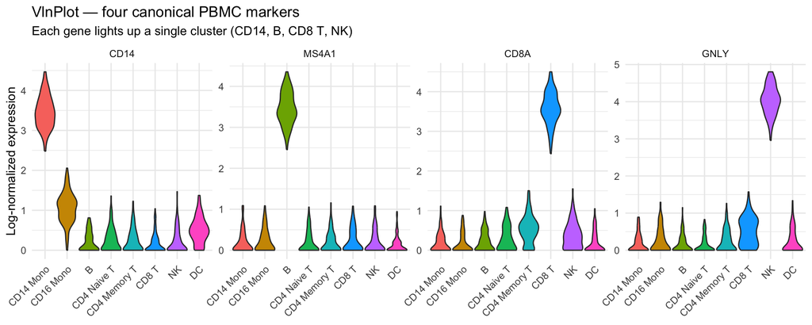

- A “good marker” violin: **one cluster bulges, the rest sit at zero**.
- If two clusters bulge similarly, the marker is shared by two cell types — keep looking for a discriminator.

## FeaturePlot — single gene on UMAP

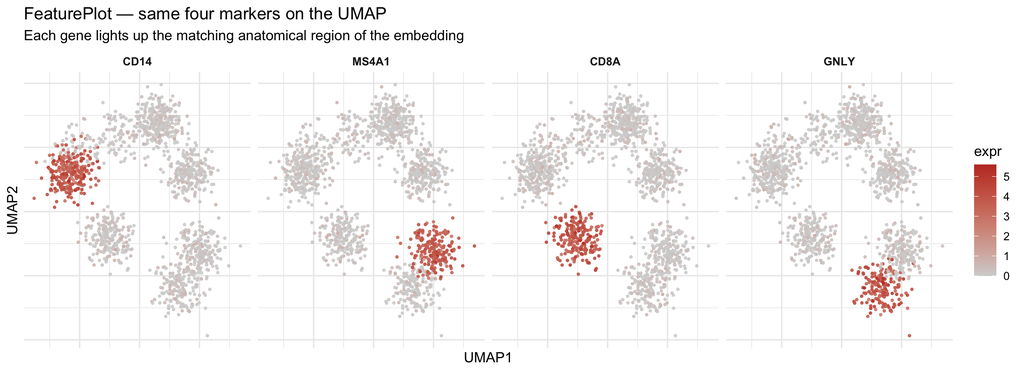

- `FeaturePlot` is the “geographic” view of a marker
- Does it have a single home on the UMAP, or is it scattered?
- Scattered = bad marker (or technical artifact).

## DotPlot — the workhorse panel figure

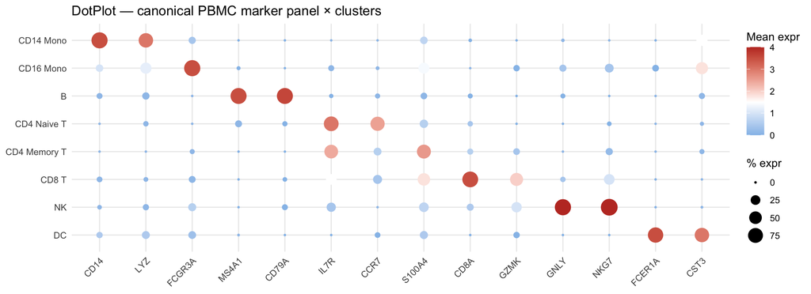

- A very good plot for a publication figure
- Panel of canonical markers along x, clusters along y, dot **size** = % cells expressing, dot **color** = mean expression.
- Eight clusters fit on one row; you can scale to 30+ clusters easily.

## Heatmap — global cluster ↔︎ marker structure

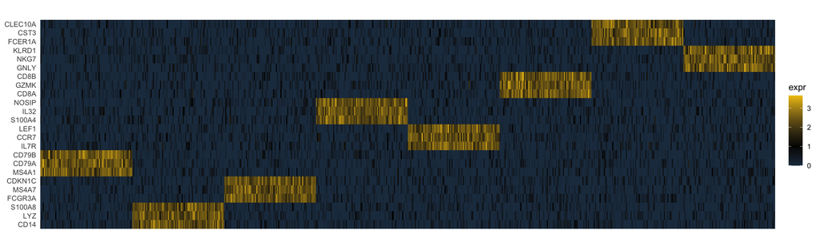

- Each cluster’s diagonal block “lights up” — its top markers are high in its cells and low elsewhere.
- A heatmap that doesn’t show this pattern means the markers aren’t actually specific to their assigned cluster.
- **One trap.** Heatmaps show *cells*, not *clusters*
- A dominant cluster (40% of cells) visually monopolizes the plot.

## Picking a plot

- **Confirming one candidate marker for one cluster** → `VlnPlot` (4 candidates side-by-side)
- **Showing where one gene “lives” on the UMAP** → `FeaturePlot`
- **Reviewer wants every cluster on one figure** → `DotPlot`
- **Showing the overall cluster ↔︎ marker block structure** → `DoHeatmap`
- **Comparing graded / continuum expression** → `RidgePlot`

**Warning**

Genes that are merely *enriched* on a Wilcoxon test are not always **markers** in the canonical sense. Cross-check at least two genes per cluster, and prefer ones that appear in published lineage panels (CellMarker 2.0, PanglaoDB).

# Assigning labels

## More clusters than cell types — the un-integrated over-split

**Warning**

- **On un-integrated data you will see more clusters than named cell types.**
- In Tutorial 03 (which follows Tutorial 02’s un-integrated clustering), a resolution of ≈ 0.5 on the ifnb dataset typically yields **~15–20 clusters** even though the data contain roughly **13 annotatable PBMC cell types**.
- The excess clusters arise because each cell type appears as a CTRL version and a STIM version — two islands in the UMAP that get separate cluster IDs. - Attempting to find conserved markers for all of them and label every one can trigger downstream errors (too few cells in a condition slice). The practical solutions:
- Use `FindConservedMarkers` only for clusters where both conditions are present in sufficient numbers.
- Accept that some cluster pairs will be annotated as the same cell type and merged before further analysis.
- Or move straight to integrated data (Tutorial 05) where CTRL and STIM cells of the same type co-cluster correctly.

## The decision loop

1. Look at top 10 markers per cluster (`slice_max`)
2. Cross-reference against **CellMarker 2.0**, **PanglaoDB**, or a tissue-specific atlas
3. Confirm with `FeaturePlot` / `DotPlot` of the canonical 2–3 markers
4. Assign — and **write down why** in your notebook

```r
new_ids <- c("0" = "CD4 T", "1" = "CD14 Mono", "2" = "B",
             "3" = "CD8 T", "4" = "NK",  "5" = "DC")
seu <- RenameIdents(seu, new_ids)
seu$celltype <- Idents(seu)
```

**Tip**

**Reference panels worth bookmarking:**

- [CellMarker 2.0](http://bio-bigdata.hrbmu.edu.cn/CellMarker/) — curated, searchable by tissue/disease
- [PanglaoDB](https://panglaodb.se/) — large, scRNA-derived
- [The Human Protein Atlas — Cell types](https://www.proteinatlas.org/humanproteome/celltype) — expression-supported markers

# Recap & what’s next

## What to remember from Lecture 03

- Clusters ≠ cell types. The biology is in the labels you give the clusters.
- `FindAllMarkers` finds *enriched* genes; `FindConservedMarkers` finds *condition-robust* ones — use the latter in case-control designs.
- Document why you assigned each label — future-you (and reviewers) will thank you
- Manual + reference-based (Lec 04) annotation are *complementary*, not redundant